# Hacklab Developer Census 2020

## What is the primary operating system in which you work?

Windows in the most used operating system. Professional developers use MacOS and Linux more often than other respondents. Students are overwhelmingly on Windows.

### All Respondents

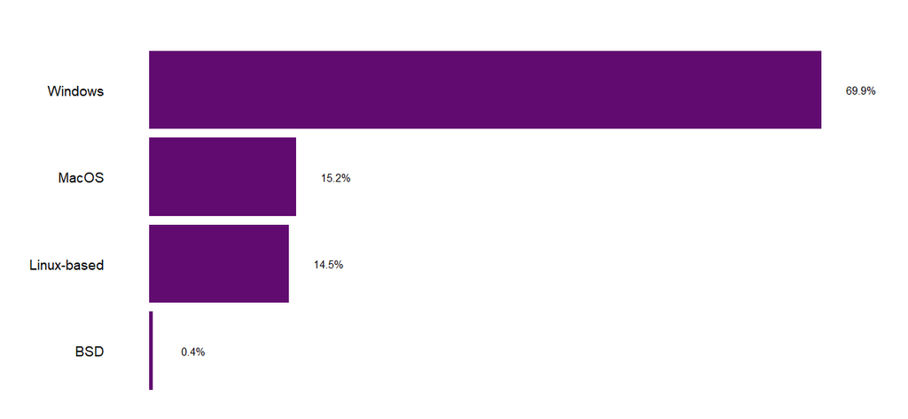

### Professional Developers

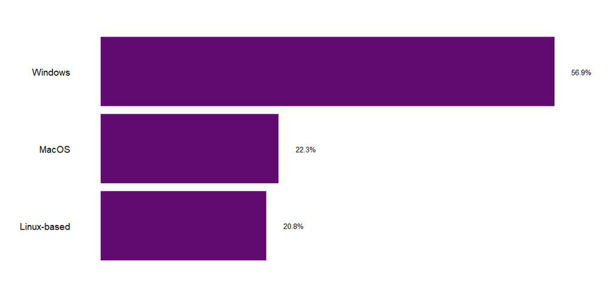

### Students

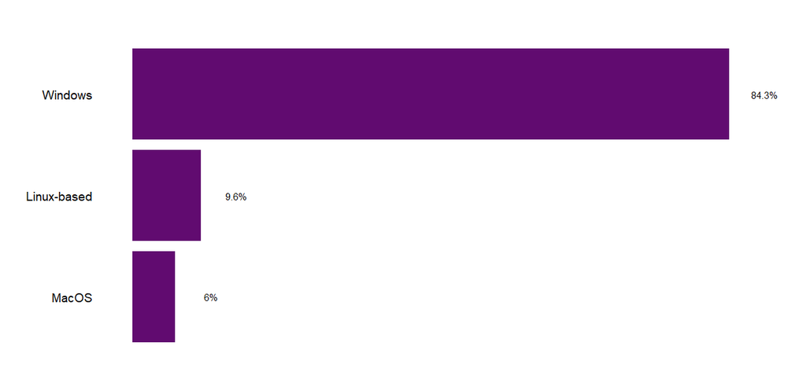

## In which operating system would you rather work?

MacOS, Linux and Windows are practically tied as preferred systems. Professional developers have a preference for MacOS, then Linux. Students prefer Windows.

### All Respondents

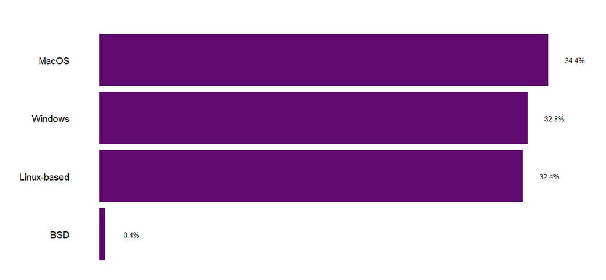

### Professional Developers

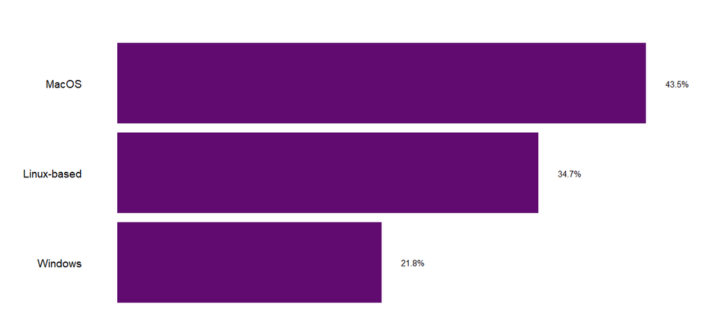

### Students

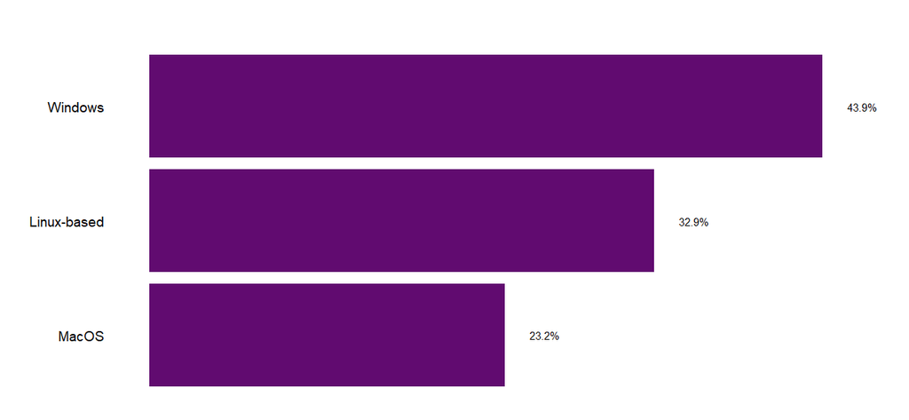

## What level of influence do you, personally, have over new technology purchases at your organization?

Unsurprisingly, professional developers are more likely to have influence over new technology purchases.

### All Respondents

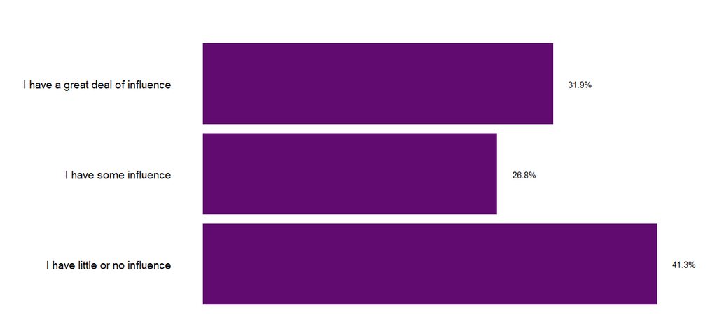

### Professional Developers

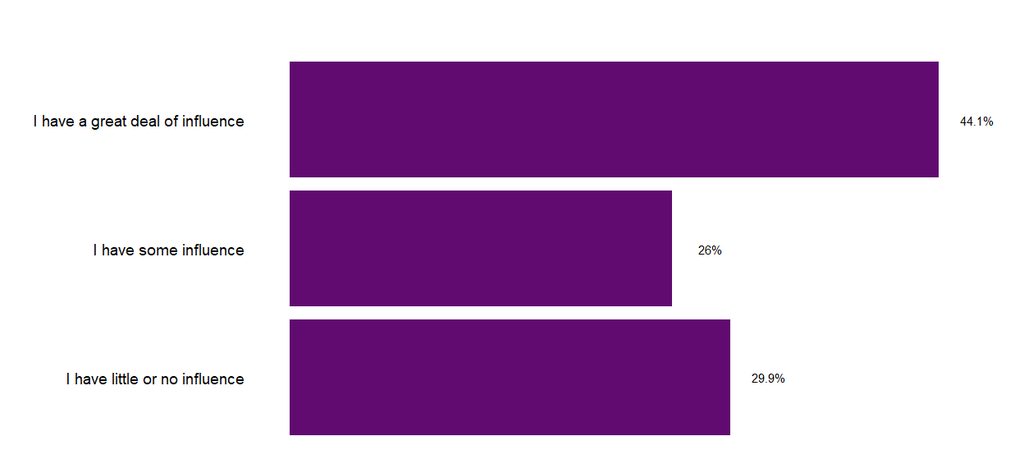

## Q17. When buying a new tool or software, how do you discover and research available solutions? Select all that apply.

[figure not shown]

# Education, Work and Career

## Q18. Which of the following best describes the highest level of formal education that you have completed?

### All Respondents

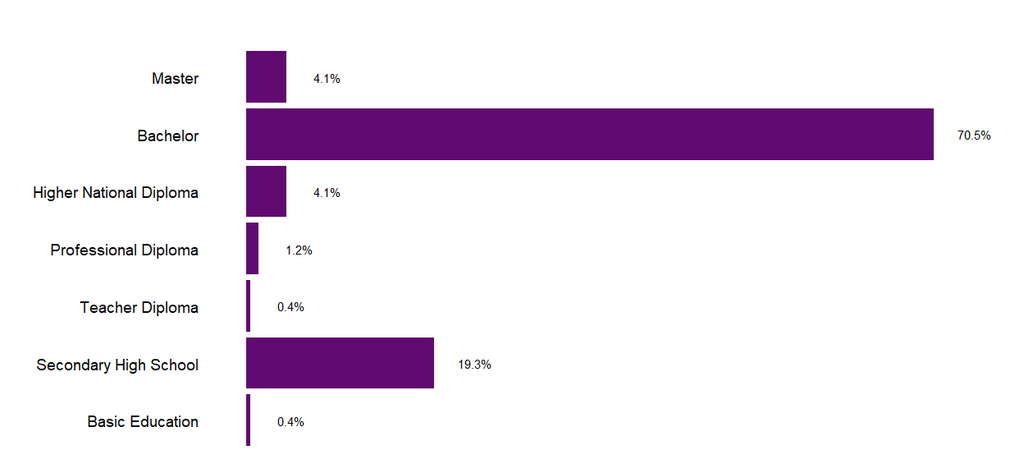

### Professional Developers

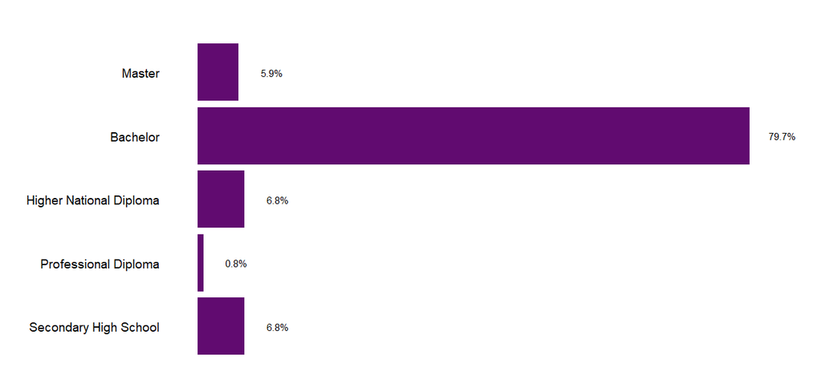

### Students

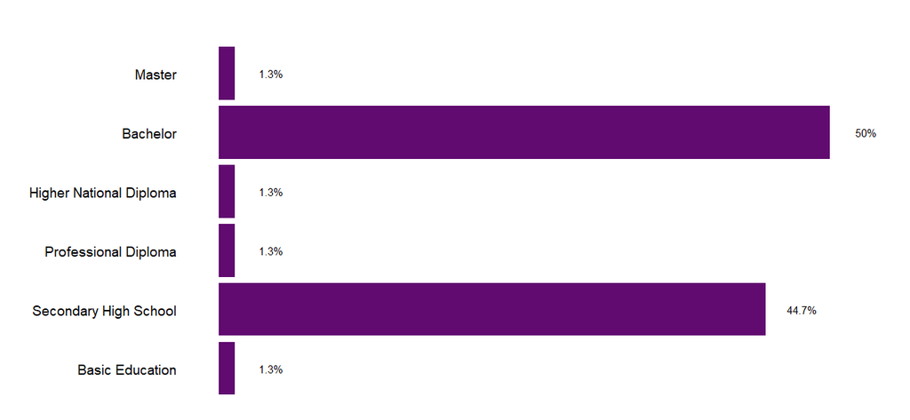

## Q19. What was your primary field of study?

Most participants study or studied Computer Science or Computer Engineering, followed by Information Technology and other Engineering fields as well as Mathematics/Statistics and Business.

### All Respondents

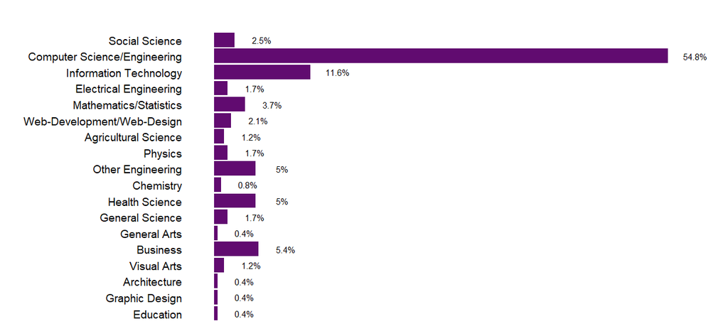

### Professional Developers

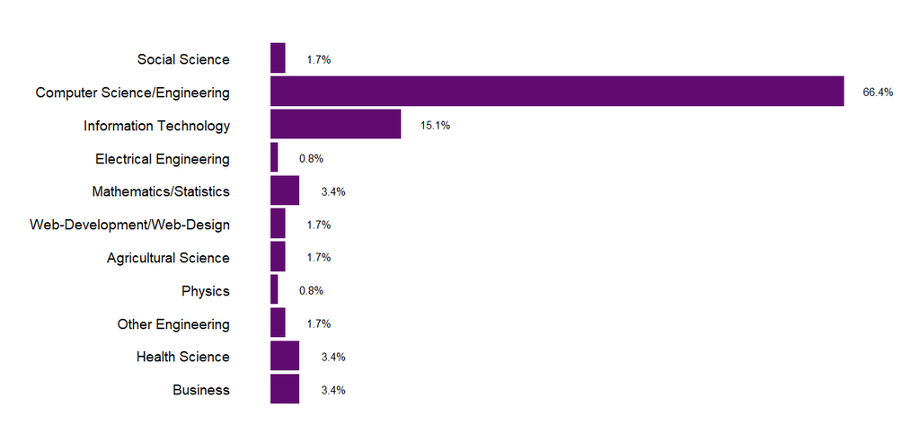

### Students

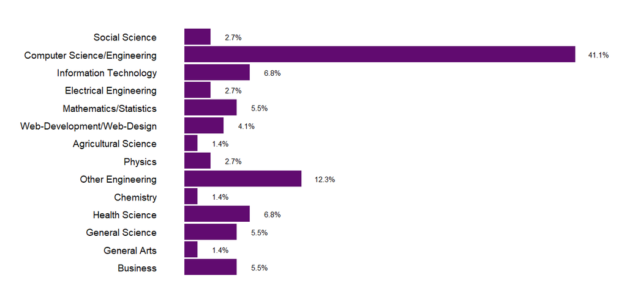

## Q20. How important is a formal education, such as a university degree in computer science, to your career?

### All Respondents

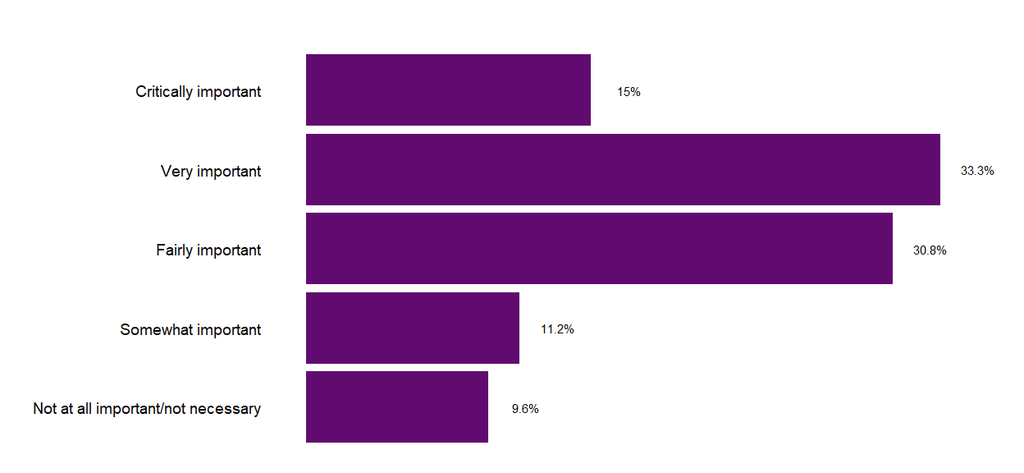

### Professional Developers

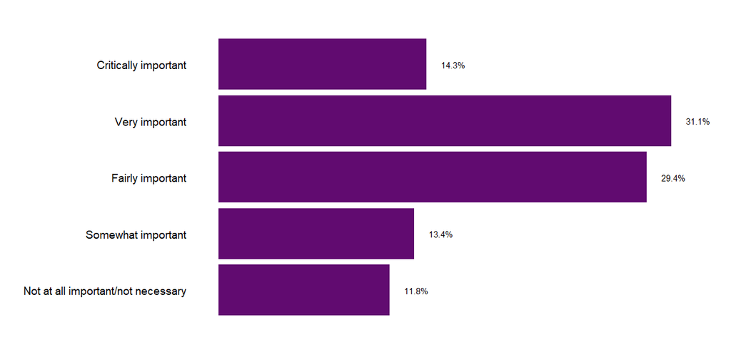

### Students

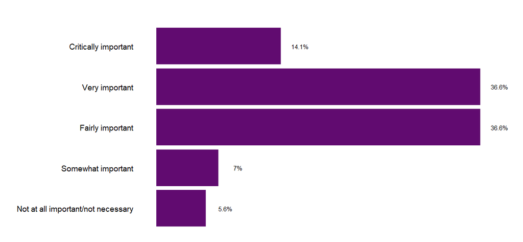

## Q21. From Q18, if you could go back and change your educational path (but end up in the same career), what would you change?

```
                                                                                                                                   change_edu_21
1                                                                                                                           Approach to learning
2                                                                                                                     Business or graphic design
3                                                                                                                               change my school
4                                                                                                 Combination of modules I select for the course
5                                                                                                                                     Curriculum
6                                                                                                                                 field of study
7                                                                                                                      How I learned programming
8                                                                                                                     How the courses are taught
9  I'd probably have studied general arts in senior high, then turned the Computer Science department ict labs into my playground in University.
10                                                                     I'll do electronic and electrical engineering instead of computer science
11                                                                                                             I will change the course I chose.
12                                                                                                I woud have added something else to my studies
13                                                                                                                   I woud not go to university
14                                                            I would change my programme of study to computer science, or software engineering.
```

[output cut: 61 more lines]

## Q22. How satisfied are you with your current job? (If you work multiple jobs, answer for one you spend the most hours on.)

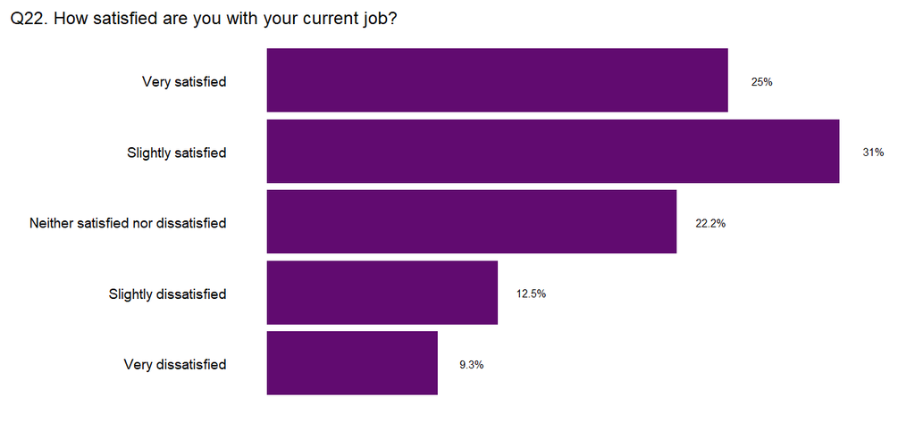

[figure not shown]

[figure not shown]

## Q23. Approximately how many people are employed by the company or organization you currently work for?

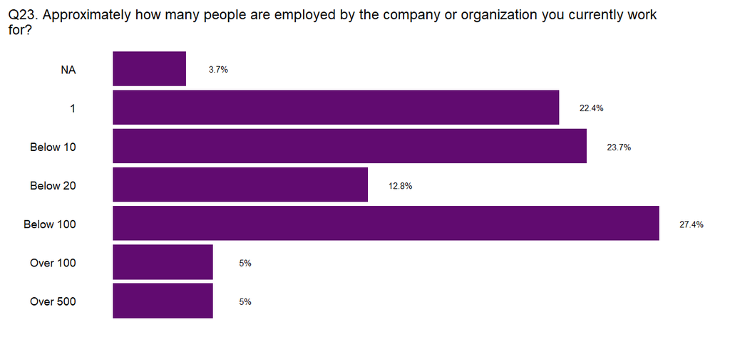

## Q24. On average, how many hours per week do you work? Please enter a whole number in the box.

```
   weekly_work_hours_24  n        perc perc_label
1                     0  2 0.009615385         1%
2                     2  1 0.004807692       0.5%
3                     4  4 0.019230769       1.9%
4                     5  4 0.019230769       1.9%
5                     6  7 0.033653846       3.4%
6                     7  1 0.004807692       0.5%
7                     8  6 0.028846154       2.9%
8                     9  6 0.028846154       2.9%
9                    10  4 0.019230769       1.9%
10                   12  4 0.019230769       1.9%
11                   15  1 0.004807692       0.5%
12                   19  1 0.004807692       0.5%
13                   20  6 0.028846154       2.9%
14                   21  1 0.004807692       0.5%
```

[output cut: 32 more lines]

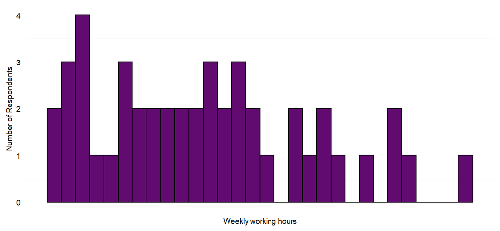

## Q25. How often do you work overtime or beyond the formal time expectation of your job?

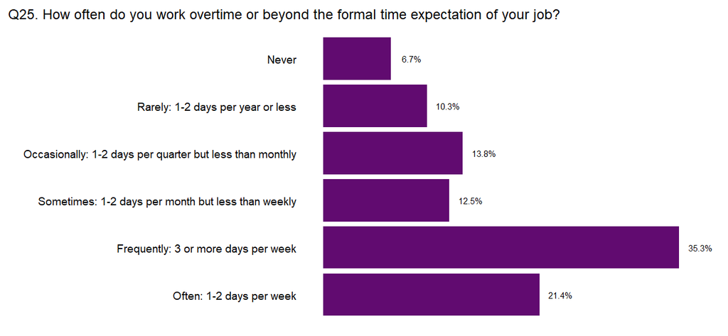

## Q26. Do you think your company has a good on-boarding process? (By on-boarding, we mean the structured process of getting you settled in to your new role at a company)

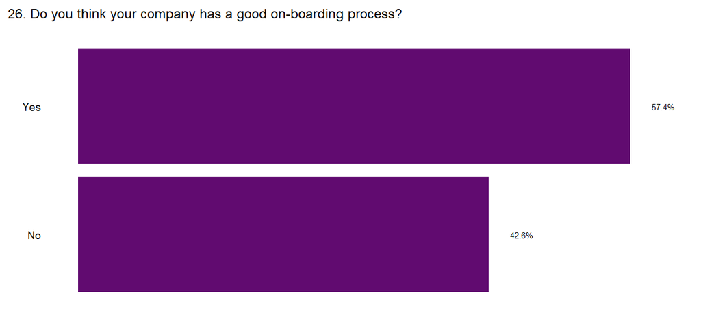

## Q27. How could on-boarding at your company be improved?

```
                                                                                                          improve_onboarding_27
1                                                                           A little interview on the chosen choice of language
2                                                                                     A standardized structure for onboard ding
3                                                                                             Adequate funds for the right role
4                                                                                    Assign mentors to newly assigned employees
5                                                                                                       Better background check
6                                                                           By applying more practical tests for the individual
7                                                       By clearly defining the core functions of the various units/departments
8                                                                                    By defining a structure in the first place
9                                                                                              By establishing an HR Department
10                                                        By improving the organisational structure to facilitate the work flow
11                                                                                                            Capacity building
12                                                                                                                Communication
13 Company needs to allow the organisational structures to work without interference and clear task to be assigned to new hires
14                                     Could have someone to take me through the code instead of having to understand it myself
```

[output cut: 117 more lines]

## Q28. How much is your monthly salary in Ghana Cedis?

### All Respondents

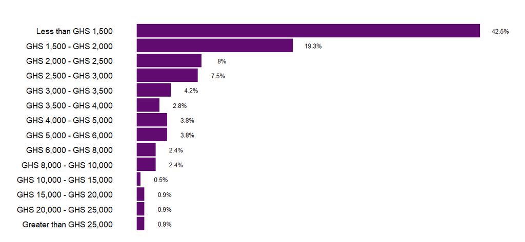

### Only Women

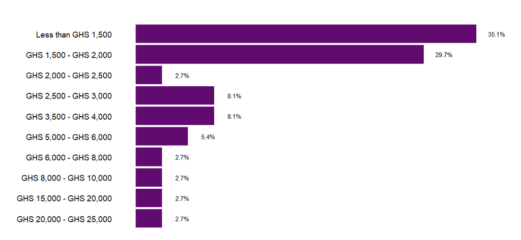

### Only Men

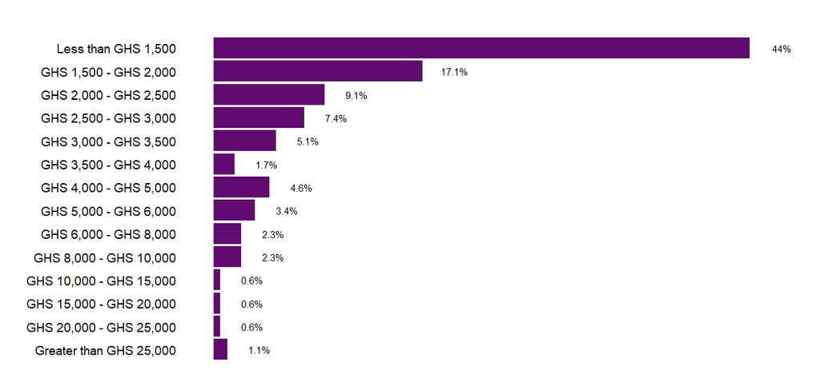

## Q29. Which of the following best describes your current job-seeking status?

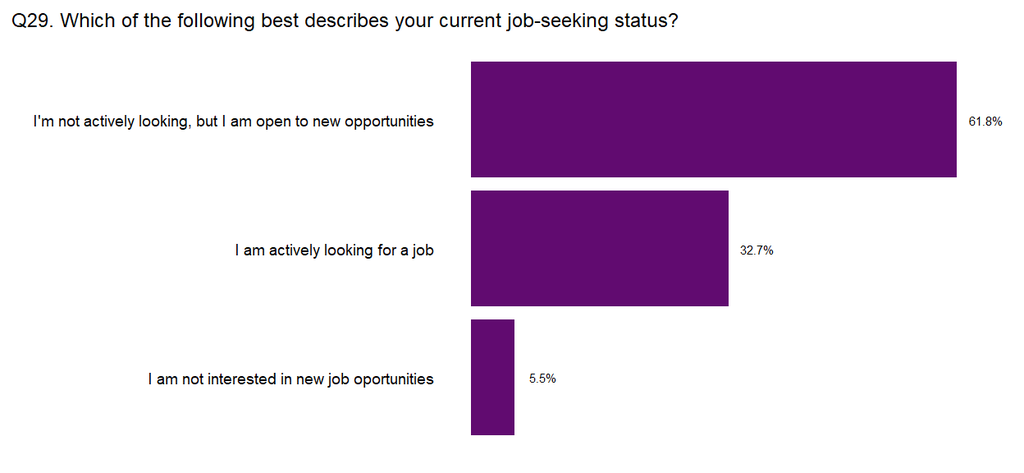

## Q30. In general, what drives you to look for a new job? Select all that apply.

### All Respondents

[figure not shown]

### Professional Developers

[figure not shown]

### Students

[figure not shown]

## Q31. When job searching, how do you learn more about a company? Select all that apply.

[figure not shown]

## Q32. Are you a member of any other online/offline developer communities?

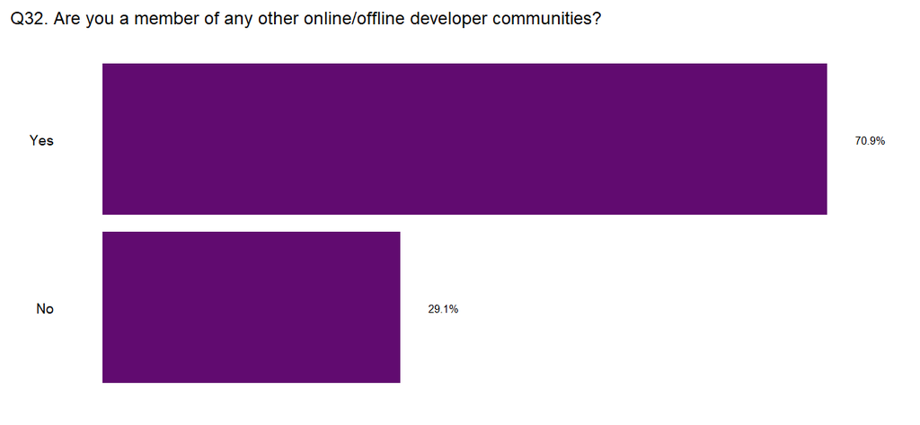

## Q33. Developer communities you are a member of

```
                                                                                                   which_dev_community_33
1                                                                                                   Accra .NET User Group
2                                                                                                   Aenics;Diversity Tech
3                                                                                               Andela Learning Community
4                                                          Andela Learning Community;DevCongress;Laravel Developers Ghana
5                       Arduino developer community;Raspberry pi developer community;Stack Exchange;Tensorflow developers
6                                                                                     AWS Accra Meetup;Hacklab Foundation
7                                                                                               Azubi Africa;Python Ghana
8                                                                                                                    Code
9                                                                                                                CodeHive
10                                                                                                               Codewars
11                                                                                                     Dev.to;DevCongress
12                                                                                               Dev.to;HackerRank;GitHub
13                                                                                                            DevCongress
14                                                          DevCongress;Developers in Vogue;Python Ghana;Women TechMakers
```

[output cut: 231 more lines]

# Demographics

## Gender

### What Gender do you identify as?

There is a greater share of women among the students than among the professional developers.

Ghana’s developer community may become more representative in the upcoming years.

### All Respondents

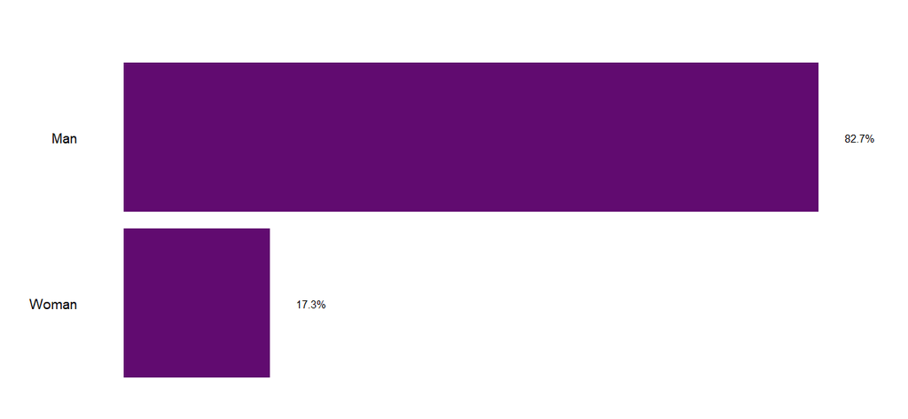

### Professional Developers

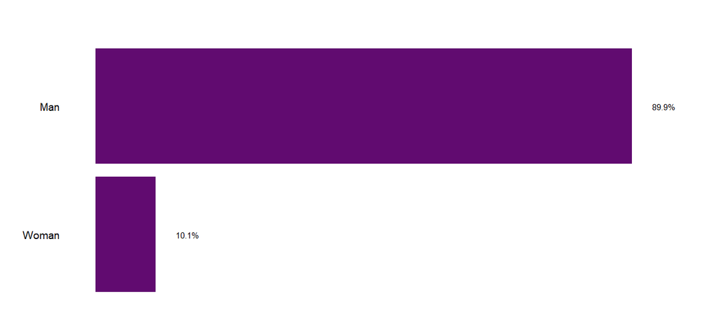

### Students

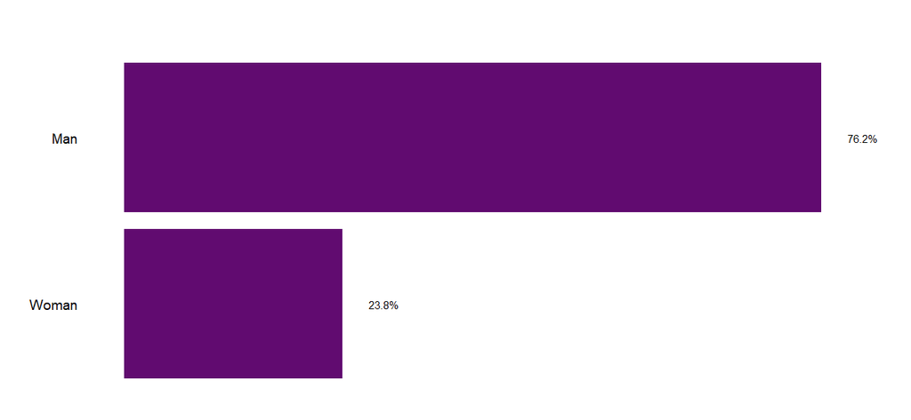

### Do you identify as transgender?

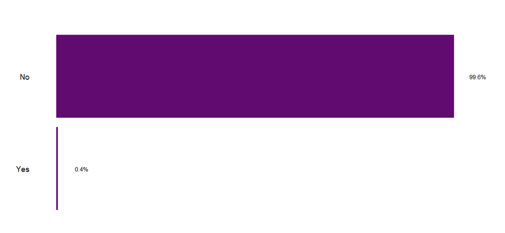

## Sexual orientation

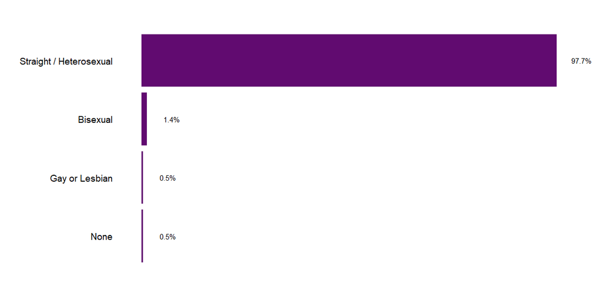

## Ethnicity

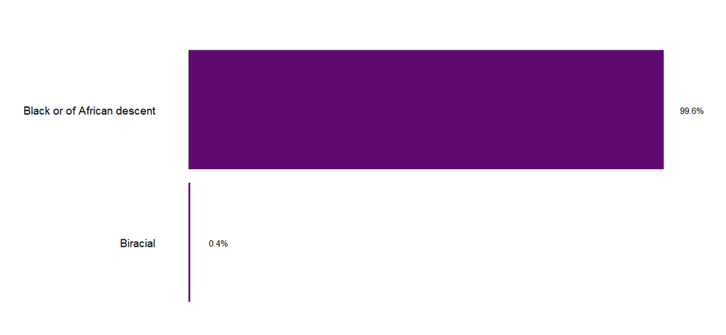

## Do you have any dependents you care for?

Among our respondents, women seem to have dependents they care for less often than men do. This may partly be due to the fact, that more women are still in their studies and that the women in our sample may be younger than the men.

### All Respondents

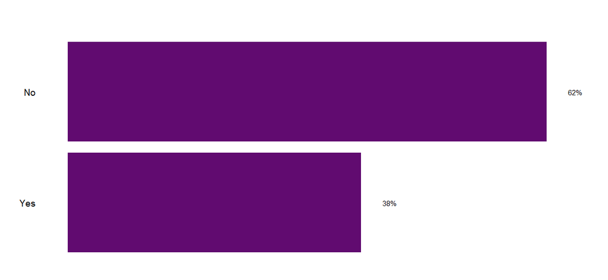

### Only Men

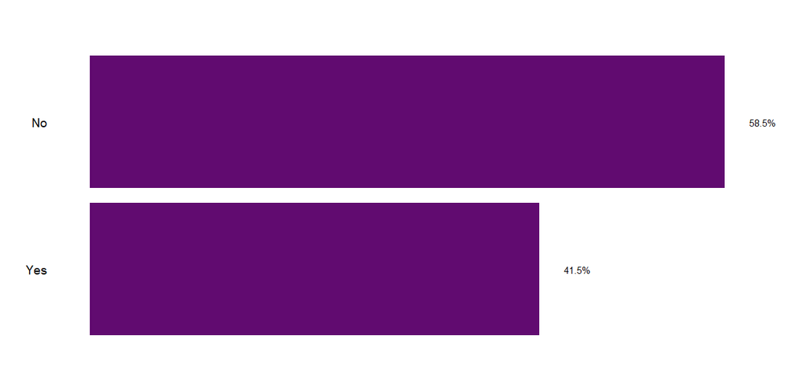

### Only Women

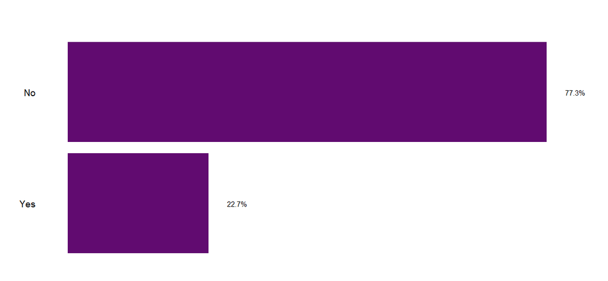